# IS71068A Data Programming (2022)

## Coursework 1

### ID: 3368 6408

## Overview

### The Project

This project is about the effects of the **Russo-Ukrainian War** on both Russia and **NATO**'s defense budgets, and gas prices throughout the European Continent. In particular, it pertains to the repercussions NATO's defense budget has on Europeans as a result of their historic dependence on Russian gas exports.

### Russo-Ukrainian War

On February 24th 2022, forces from the **Russian Federation** invaded **The Ukraine** from its Eastern borders. In the months following, four oblasts (regions) - **Donestk**, **Kherson**, **Luhansk** and **Zaporizhzhia** - were formally annexed and absorbed, along with **Crimea** (annexed 2014), into the Russian Federation. Although, this annexation of Ukrainian territory remains unrecognized by the international community, spare North Korea.

Below is a summary of key events which have occured since the begining of the war.

- Origins
  - 20/02/2014 - Russia invades Crimea
  - 18/03/2014 - Russia annexes Crimea
- Build-up
  - 03/03/2021 to 26/10/2021 - Build-up of Russian forces along the Ukrainian border
  - 21/02/2022 - Donetsk and Luhansk are formally recognized as independent states by Russia
- Invasion
  - 24/02/2022 - A full-scale invasion is launched against Ukraine by Russia
  - 30/09/2022 - Russia claims/annexes four regions of Eastern Ukraine
- Ongoing...
  - 26/10/2022 - NATO and Russia conducting nuclear drills
  - 29/10/2022 - Russia withdraws from UN deal to protect grain exports from Ukraine
  - 02/11/2022 - Russia re-enters UN grain export deal

Ongoing, the Russo-Ukrainian War is the greatest conflict on European soil since the Second World War (which involved the **United States**, the **British Empire** and the **Soviet Union** against **National Socialist (Nazi) Germany** and **Fascist Italy**), with this status stirring deepened concerns from the Western forces of NATO and allies.

### Nord Stream 1 & 2

European dependence on Russian natural gas was facilitated by the pipelines **Nord Stream 1** and **Nord Stream 2**, which were shut down and subsequently severely comprimised by suspected saboteurs (now assumed by Russia to have been the British Royal Navy [5]). As a consequence of gas from Russia being cut completely, gas prices in Europe have increased significantly.

### Russia-NATO tensions

The North Atalantic Trade Organisation or NATO was founded in the light of WW2 in April of 1949 as an oppositional alliance between the Western nations - of democratic, capitalist orientation - and the Eastern nations (including Russia) of authortarian, socialist/communist orientation. The Soviet Union had annexed all of Eastern Europe, including East Germany (then the German Democratic Republic), and it was NATO that was formed to monitor and decelerate any attempts by the Soviets to further expand their influence to the West. The equivalent to NATO for the Eastern bloc was the **Warsaw Pact**, formed by the USSR, Poland, Bulgaria, Hungary, Romania, Albania, East Germany, and Czechoslovakia.

Throughout the Cold War (1947-1991) and up until today, tensions have remained consistent between the two ideologies, and for nearly a decade since 2014 Crimean War these tensions have been particularly present between Russia and NATO (with the USA spearheading the organisation's stance in the world). The tensions are partly geopolitical, stemming from the presence of NATO in the EU and former USSR states (Ukraine, Belarus, Latvia, Estonia, etc), and Russia's assaults on Ukraine. It is these tensions which serve as ground to explore correlation between the two side's military budgets, and the energy prices in Europe which have risen significantly due to Russian sanctions.

Russia is largely invulnerable as far as invasion goes - it is surrounded by artic sheilds to the North and East, and both mountainous ranges and allies to the South, making the act of ground invasion largely impractical. However, there exists a small corridor to its West which leads all the way into the capital Moscow, known as the **East European Plain**. Russian incentive to annex or gain significant influence in East Europe centers around this geography - they want buffer states to prevent or hinder invasion from the West. Hence, the attempts of Ukraine - which lies on Russia's doorstep - to edge closer to the influence of the West (European Union and NATO) stirs concern in Russia. The invasion of Ukraine is partly justified by Russian officials due to the history which Ukraine shares with Russia, with the latter claiming the former as a long lost sibling.

## Problem Area

### Economic Polemology

**Polemology** is the study of warfare, and this project focuses on the economic factors arising from observations in the Russo-Ukrainian War, and how fluctuating tensions between Russia and NATO influence these observations.

### Question

What correlations exist (if any) between the following observations from **January 2021**?:

- NATO defense expenditure
- Russian defense expenditure
- European gas prices

Provided correlation exists between one or more pairings for these data sets, a regressional model could be developed to better generalize their relationship. Additionally, these findings would be basis for further research into the economic effects of the war on a wider scale (e.g., how does gas price effect home economics for families across Europe?).

The expectation is that there should exist *some form of correlation* between these three data sets. European gas prices are affected by the war in Ukraine, which is related to Russia's military presence (and thus expenditure), which in turn arises from its mutually negative status with NATO and its military spending.

# Methods

### Exploratory Data Analysis

**Exploratory Data Analysis (EDA)** involves the high-level summary of data. This includes the following:

- creating visualizations for the data sets
- summarising key aspects (e.g., central tendencies, standard deviation)
- drawing relationships between observations and response variables
- establishing a basis for deeper analysis

Visualization, **central tendency** (e.g., arithmetic mean, median, mode), and **standard deviation** are crucial to EDA as they effectively and succinctly communicate data, in one image or value. Visualization enables us to observe trends and distributions in data sets. Central tendency provides insight to the value(s) which are representative of our data. Standard deviation signals to us how much stochastic observations deviate from an established central tendency (specifically the arithmetic mean).

### Standard Deviation

The standard deviation ($\sigma$) of a data set measures the dispertion of values relative to its arithmetic mean. Equal to the square root of **variance**, the standard deviation of a set of values is given by:

$$\sigma = \sqrt{\frac{\sum_{i=1}^{i=n}(x_{i}-\mu)^{2}}{n}}$$

where $\mu$ is the population mean of the data set, which contains $n$ observed values.

### Correlation

The correlation between two stochastic variables measures how they affect each other. Correlation may be non-existent ($0$), positive ($+ve$), such that the two variables trend with a positive gradient, or negative ($-ve$), such that the two variables trend with a negative gradient. The correlation is seldom perfect (magnitude 1), and in instances where it is perfect, suspicion should be raised as to the viability of the data used.

For continuous, regressional data, it is required that said data be **normalized** before any correlations can be drawn. Normalized data adheres to a frequency distribution of values close to its second quartile (central tendency), and exhibits little to no **skewness**.

For linear models, we use the **Pearson Correlation Coefficient**, given by the following expression:

$$r_{xy} = \frac{n\sum_{i=1}^{i=n}x_{i}y_{i} - \sum_{i=1}^{i=n}x_{i}\sum_{i=1}^{i=n}y_{i}}{\sqrt{n\sum_{i=1}^{i=n}x_{i}^{2} - (\sum_{i=1}^{i=n}x_{i})^{2}}\sqrt{n\sum_{i=1}^{i=n}y_{i}^{2}-(\sum_{i=1}^{i=n}y_{i})^{2}}}$$

which measures the correlation (mutual effect) between a given input $x_{i}$ and its corresponding output $y_{i}$, for $n$ observations in the provided data set.

### Skewness

Skewness measures the imbalance of a dataset from being normally distributed. A Gaussian distribution exhibiting a (near) perfect bell curve when plotted would possess zero skewness, for instance. Skewness may be either positive ($+ve$) wherein the tail of the dataset is longer on the right, or negative ($-ve$) wherein it is longer on the left.

**Galton Skewness** (AKA **Bowley's Skewness**) considers the upper and lower quartiles ($Q_1$ and $Q_3$) and the median ($Q_2$) of the dataset:

$$GS := \frac{Q_1 + Q_3 - 2Q_2}{Q_3 - Q_1}$$

### Python Libraries

The **Pandas** and **Numpy** libraries are used throughout the analysis involved in this project. Pandas provides convenient means of reading data from a CSV (Comma Separated Value) file into an entity known as a **data frame**, which serves to organize the data in a tabular format, and it additionally provides functions suitable for EDA (e.g., plotting, correlation, standard deviation, central tendencies). Numpy is utilized for calculating the arithmetic mean of data columns, which is useful for succinctly describing a range of observations with one value.

## Analysis of Data

### NATO and Russian Military Expenditures

Data for NATO defense spending across all member nations is provided courtesy of NATO itself [1], whereas the data pertaining to Russia's defense spending is not entirely available. The Russian budget [2] is provided as an informed estimate courtesy of the **Stockholm International Peace Research Instutute (SIPRI)**, which abides by NATO's standards of which resources contribute to military spending:

- Peacekeeping forces
- Paramilitary
- Military research
- Development
- Aid
- Maintenance
- Space operations

Data for NATO expenditure is given below:

```
Overview:
   Year         Cost
0  2014   943.217299
1  2015   895.675846
2  2016   911.653708
3  2017   918.033053
4  2018   972.422445
5  2019  1052.560913
6  2020  1096.594001
7  2021  1155.279595
8  2022  1189.875017

Correlation matrix:
          Year      Cost
Year  1.000000  0.928452
Cost  0.928452  1.000000

Skewness of Cost:
0.5242721910545268
```

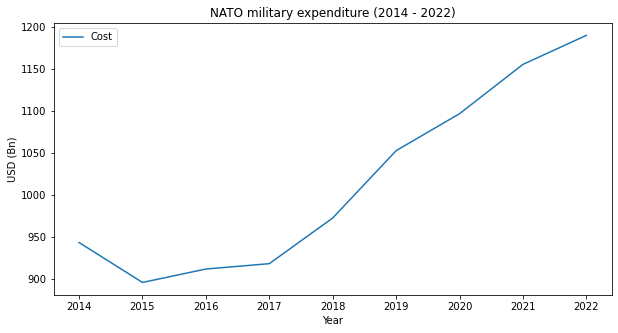

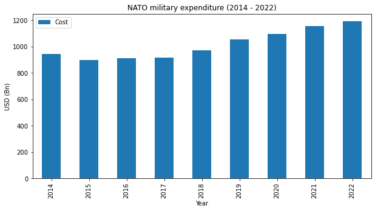

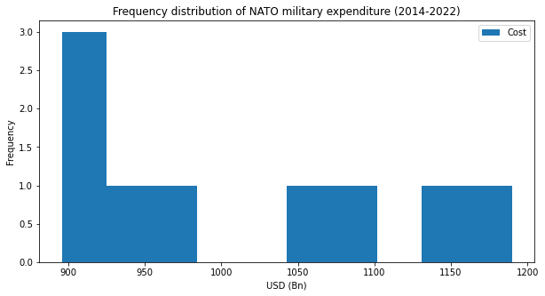

```python
import pandas as pd

NATO_budget_CSV_path = "datasets/NATO_military_budget_by_billion_dollars.csv"

try:
    with open(NATO_budget_CSV_path, mode = "r") as f:
        NATO_budget_df = pd.read_csv(f)

        # Console output
        print("\nOverview:")
        print(NATO_budget_df)
        print("\nCorrelation matrix:")
        print(NATO_budget_df.corr())
        print("\nSkewness of Cost:")
        print(NATO_budget_df["Cost"].skew())

        # Plots
        NATO_budget_df.plot.line(x = "Year", y = "Cost", title = "NATO military expenditure (2014 - 2022)", figsize=(10,5)).set_ylabel("USD (Bn)")
        NATO_budget_df.plot.bar(x = "Year", y = "Cost", title = "NATO military expenditure (2014 - 2022)", figsize=(10,5)).set_ylabel("USD (Bn)")
        NATO_budget_df.plot.hist(x = "Year", title = "Frequency distribution of NATO military expenditure (2014-2022)", figsize=(10,5)).set_xlabel("USD (Bn)")

except FileNotFoundError:
    print("Could not find file: " + NATO_budget_CSV_path)
    print("Check path spelling or directory contents.")
```

Data for Russian Expenditure is given below:

```python
import pandas as pd

RUS_budget_CSV_path = "datasets/Russia_military_budget_by_billion_dollars.csv"

try:
    with open(RUS_budget_CSV_path, mode = "r") as f:
        RUS_budget_df = pd.read_csv(f)

        # Console output
        print("\nOverview:")
        print(RUS_budget_df)
        print("\nCorrelation matrix:")
        print(RUS_budget_df.corr())
        print("\nSkewness of Cost:")
        print(RUS_budget_df["Cost"].skew())

except FileNotFoundError:
    print("Could not find file: " + RUS_budget_CSV_path)
    print("Check path spelling or directory contents.")
```

```
Overview:
   Year   Cost
0  2014  84.70
1  2015  66.42
2  2016  69.25
3  2017  66.91
4  2018  61.61
5  2019  65.20
6  2020  61.71
7  2021  65.91
8  2022  90.90

Correlation matrix:
          Year      Cost
Year  1.000000  0.028627
Cost  0.028627  1.000000

Skewness of Cost:
1.4787649044219509
```

The Russian government has not released any data on its military spending since May 2022, and thus official figures are unavailable for analysis. It is expected, though, that due to the trend this budget has followed since the Crimean conflict, it may very well be equal to or greater than the most recent record released [4].

According to [4] and [6], the initial Russian defence budget for 2022 was approximately 63.6Bn USD, although in light of the war this can very well vary, with the greatest estimate being 90.9Bn USD by the end of 2022. Below we apply the latter estimate of £90.9Bn as a reasonable assumption for the 2022 defense budget of Russia. At the time of writing it is currently not possible to access [6] via browser or webscraping, perhaps due to regional restrictions.

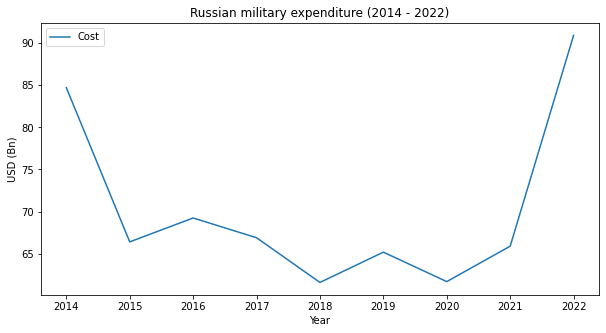

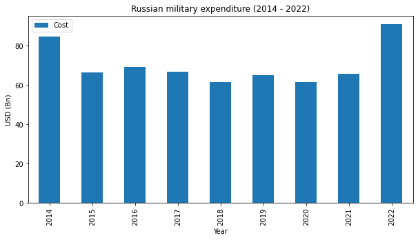

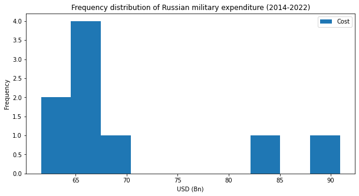

```python
# Plots
RUS_budget_df.plot.line(x = "Year", y = "Cost", title = "Russian military expenditure (2014 - 2022)", figsize=(10,5)).set_ylabel("USD (Bn)")
RUS_budget_df.plot.bar(x = "Year", y = "Cost", title = "Russian military expenditure (2014 - 2022)", figsize=(10,5)).set_ylabel("USD (Bn)")
RUS_budget_df.plot.hist(x = "Year", title = "Frequency distribution of Russian military expenditure (2014-2022)", figsize=(10,5)).set_xlabel("USD (Bn)")
```

Plotted together, we can compare the Russia's and NATO's military budgets:

```
Overview:
   Year  Russian Budget  NATO Budget
0  2014           84.70   943.217299
1  2015           66.42   895.675846
2  2016           69.25   911.653708
3  2017           66.91   918.033053
4  2018           61.61   972.422445
5  2019           65.20  1052.560913
6  2020           61.71  1096.594001
7  2021           65.91  1155.279595
8  2022           90.90  1189.875017

Correlation matrix:
                    Year  Russian Budget  NATO Budget
Year            1.000000        0.028627     0.928452
Russian Budget  0.028627        1.000000     0.252699
NATO Budget     0.928452        0.252699     1.000000
```

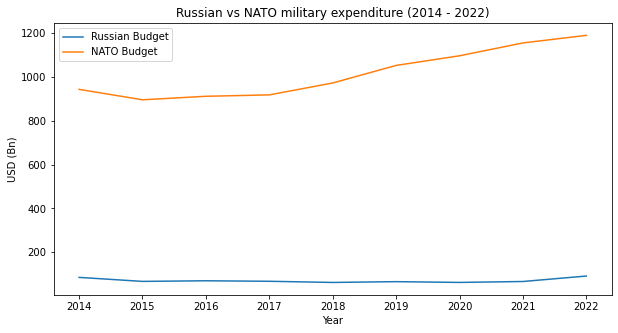

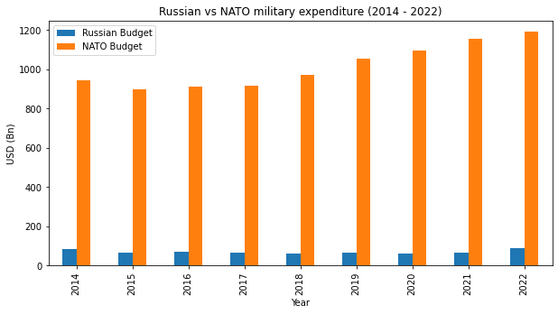

```python
import pandas as pd

# A single CSV file containing both NATO and Russia's defense budgets from 2014 to 2022
Compared_budgets_CSV_path = "datasets/Compared_military_budgets_by_billion_dollars.csv"

try:
    with open(Compared_budgets_CSV_path, mode = "r") as f:
        comparison_df = pd.read_csv(f)

        # Console output
        print("\nOverview:")
        print(comparison_df)
        print("\nCorrelation matrix:")
        print(comparison_df.corr())

        # Plots
        comparison_df.plot.line(x = "Year", y = ["Russian Budget", "NATO Budget"], title = "Russian vs NATO military expenditure (2014 - 2022)", figsize=(10,5)).set_ylabel("USD (Bn)")
        comparison_df.plot.bar(x = "Year", y = ["Russian Budget", "NATO Budget"], title = "Russian vs NATO military expenditure (2014 - 2022)", figsize=(10,5)).set_ylabel("USD (Bn)")

except FileNotFoundError:
    print("Could not find file: " + Compared_budgets_CSV_path)
    print("Check path spelling or directory contents.")
```

Summary of NATO budget

```python
print(comparison_df["NATO Budget"].describe())
```

```
count       9.000000
mean     1015.034653
std       111.587932
min       895.675846
25%       918.033053
50%       972.422445
75%      1096.594001
max      1189.875017
Name: NATO Budget, dtype: float64
```

Summary of Russian budget

```python
print(comparison_df["Russian Budget"].describe())
```

```
count     9.000000
mean     70.290000
std      10.331713
min      61.610000
25%      65.200000
50%      66.420000
75%      69.250000
max      90.900000
Name: Russian Budget, dtype: float64
```

The correlation between the NATO and Russian budgets are given as follows:

```python
print("Correlation: " + str(comparison_df["NATO Budget"].corr(comparison_df["Russian Budget"])))
```

```
Correlation: 0.2526993162419751
```

This implies that the two budgets share a **weak positive correlation**: where Russia's budget increases relatively slightly, NATO's budget increases greatly.

Although, care must be taken not to infer causation from this. Correlation is *not* causation.

Below is a bar chart visualizing how the average defense budgets of NATO and Russia compare.

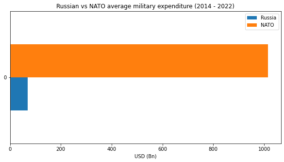

```python
import numpy as npy

average_RUS_budget = npy.mean(RUS_budget_df["Cost"])
average_NATO_budget = npy.mean(NATO_budget_df["Cost"])

average_budgets = {"NATO" : [average_NATO_budget],
                    "Russia" : [average_RUS_budget]}

average_budgets_df = pd.DataFrame(average_budgets)
average_budgets_df.plot.barh(y = ["Russia", "NATO"], title = "Russian vs NATO average military expenditure (2014 - 2022)", figsize=(10,5)).set_xlabel("USD (Bn)")
```

### European TTF Gas Prices

Reference is paid to the European TTF (AKA, Dutch Title Transfer Facility), which acts as a benchmark proxy for historic and present natural gas prices across the European Union (EU). Prices are stated in Euros per Megawatt-hours (how much it costs to run a megawatt for a single hour).

The data set for these prices was acquired through [3], and comprises of monthly records from November 2017 up until October 2022.

```
Overview:
          Date     Cost     Open     High      Low    Vol. Change %
0   01/11/2017   20.305   20.305   20.305   20.305           11.05%
1   01/12/2017   19.620   19.620   19.620   19.620           -3.37%
2   01/01/2018   17.880   17.880   17.880   17.880           -8.87%
3   01/02/2018   17.350   17.350   17.350   17.350           -2.96%
4   01/03/2018   18.225   18.225   18.225   18.225   0.18K    5.04%
5   01/04/2018   20.560   19.520   19.835   19.520   0.07K   12.81%
6   01/05/2018   22.580   21.135   22.260   20.840   0.09K    9.82%
7   01/06/2018   21.875   21.630   21.630   21.630   0.04K   -3.12%
8   01/07/2018   22.115   22.300   22.300   22.300   0.02K    1.10%
9   01/08/2018   25.835   22.000   26.025   22.000   0.22K   16.82%
10  01/09/2018   27.330   26.965   29.560   26.655   0.94K    5.79%
11  01/10/2018   24.335   26.735   27.860   25.625   0.12K  -10.96%
12  01/11/2018   24.690   23.975   26.725   23.625   0.59K    1.46%
```

[output cut: 57 more lines]

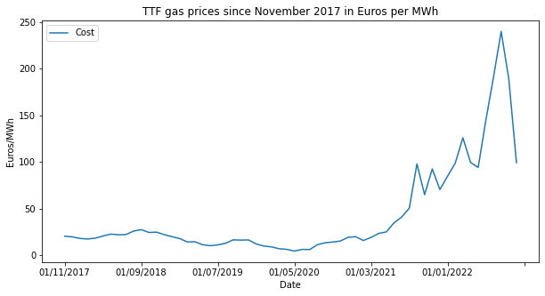

```python
import pandas as pd
import numpy as npy

Gas_prices_CSV_path = "datasets/Dutch_TTF_gas_prices.csv"

try:
    with open(Gas_prices_CSV_path, mode = "r") as f:
        ttf_gas_df = pd.read_csv(f, keep_default_na = False)

        # Console output
        print("\nOverview:")
        print(ttf_gas_df)
        print("\nCorrelation matrix:")
        print(ttf_gas_df.corr())
        print("\nSkewness of Cost:")
        print(ttf_gas_df["Cost"].skew())

        # Plots
        ttf_gas_df.plot.line(x = "Date", y = "Cost", title = "TTF gas prices since November 2017 in Euros per MWh", figsize=(10,5)).set_ylabel("Euros/MWh")

except FileNotFoundError:
    print("Could not find file: " + Gas_prices_CSV_path)
    print("Check path spelling or directory contents.")
```

```
Overview:
   Year  Average Cost
0  2017     19.962500
1  2018     22.062917
2  2019     14.357500
3  2020     10.097917
4  2021     46.161667
5  2022    136.593000
```

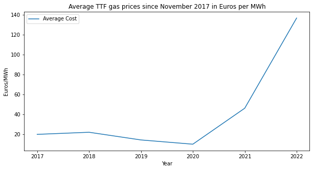

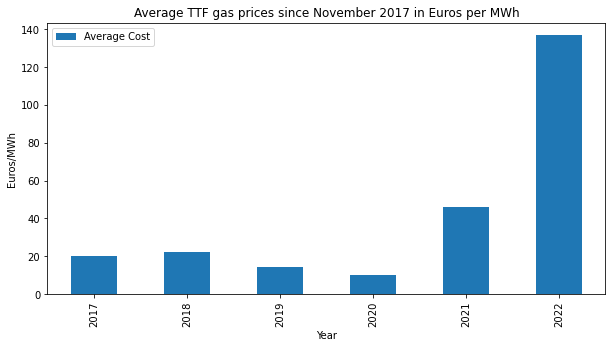

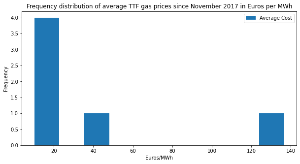

```python
# create a new dictionary for containing average gas prices per year
yearly_ttf_gas_data = {"Year":["2017", "2018", "2019", "2020", "2021", "2022"],
                        "Average Cost":[]}

# empty containers for average prices of gas for each year
listof_2017_prices = []
listof_2018_prices = []
listof_2019_prices = []
listof_2020_prices = []
listof_2021_prices = []
listof_2022_prices = []

# iterate through the contents of the data frame
for i in range(len(ttf_gas_df)):
    date = ttf_gas_df.iloc[i]["Date"]
    if(date.__contains__("2017")):
        listof_2017_prices.append(ttf_gas_df.iloc[i]["Cost"])
    elif(date.__contains__("2018")):
        listof_2018_prices.append(ttf_gas_df.iloc[i]["Cost"])
    elif(date.__contains__("2019")):
        listof_2019_prices.append(ttf_gas_df.iloc[i]["Cost"])
    elif(date.__contains__("2020")):
        listof_2020_prices.append(ttf_gas_df.iloc[i]["Cost"])
    elif(date.__contains__("2021")):
        listof_2021_prices.append(ttf_gas_df.iloc[i]["Cost"])
    elif(date.__contains__("2022")):
        listof_2022_prices.append(ttf_gas_df.iloc[i]["Cost"])

yearly_ttf_gas_data["Average Cost"].append(npy.mean(listof_2017_prices))
yearly_ttf_gas_data["Average Cost"].append(npy.mean(listof_2018_prices))
yearly_ttf_gas_data["Average Cost"].append(npy.mean(listof_2019_prices))
yearly_ttf_gas_data["Average Cost"].append(npy.mean(listof_2020_prices))
yearly_ttf_gas_data["Average Cost"].append(npy.mean(listof_2021_prices))
yearly_ttf_gas_data["Average Cost"].append(npy.mean(listof_2022_prices))

# create data frame containing average gas prices
yearly_ttf_gas_df = pd.DataFrame(yearly_ttf_gas_data)

# Console output
print("\nOverview:")
print(yearly_ttf_gas_df)

# Plots
yearly_ttf_gas_df.plot.line(x = "Year", y = "Average Cost", title = "Average TTF gas prices since November 2017 in Euros per MWh", figsize=(10,5)).set_ylabel("Euros/MWh")
yearly_ttf_gas_df.plot.bar(x = "Year", y = "Average Cost", title = "Average TTF gas prices since November 2017 in Euros per MWh", figsize=(10,5)).set_ylabel("Euros/MWh")
yearly_ttf_gas_df.plot.hist(x = "Year", title = "Frequency distribution of average TTF gas prices since November 2017 in Euros per MWh", figsize=(10,5)).set_xlabel("Euros/MWh")
```

### Military Budget vs Gas Prices

How do NATO and Russian military expenditures compare to the yearly average gas prices in Europe?

The correlation for NATO is given below

```python
# measure the correlation between NATO budget and European gas prices
yearly_ttf_gas_df["Average Cost"].corr(NATO_budget_df.drop([0,1,2])["Cost"])
```

```
0.9911457127038404
```

and for Russia

```python
# measure the correlation between Russian military budget and European gas prices
yearly_ttf_gas_df["Average Cost"].corr(RUS_budget_df.drop([0,1,2])["Cost"])
```

```
-0.07828369054666177
```

## Hypothesis

Due to the war-centric relationship between NATO and Russia...

decisions by NATO to increase spending have economic repercussions for European members as a direct result of Russian tactics.

The economic, environmental, and health related effects of hightened cost in natural gas in Europe may be further explored with other factors taken into consideration, such as

- the cost of living
- renewable energy usage
- carbon emissions
- health issues or deaths due to cold temperatures

Although, war has sociological effects, too. The hypothesis that NATO's military budget directly affects Europe's economy (due to her historic dependence on Russian exports) has social parameters which can be investigated under the foundation of these findings:

- anti-Russian sentiment
- anti-Ukrainian sentiment
- anti-West sentiment
- refugees from Eastern Europe

For example: European citizens feeling the effects of the war, be they economic or personal, would exhibit political alignment which influences their sentiment. Some people may agree or disagree with the war in Ukraine. Some people may find themselves being highly critical of Russian individuals (Russophobia), even those who are not directly involved with the conflict.

## Summary

This question will be answered in further work, where the technique of **sentiment analysis** will be applied to classify statements from sources (such as newspaper tabloids, social media, etc) into categories:

- anti-Russian
- pro-Russian
- neutral/indifferent

These classifications could also be cross-referenced with opinion polls in empirical data gathering. Questionnaires may be applied to gather opinions from individuals about the war.

# References

[1] NATO, "Defence Expenditures of NATO Countries (2014-2022)", 2022. [Online]. Available: https://www.nato.int/cps/en/natohq/news_197050.htm [Accessed: 26-Oct-2022]

[2] MacroTrends, "Russia Military Spending/Defense Budget 1993-2022", 2022. [Online]. Available: https://www.macrotrends.net/countries/RUS/russia/military-spending-defense-budget [Accessed: 26-Oct-2022]

[3] UK Investing.com, "Dutch TTF Natural Gas Futures - Nov 22 (TFAc1)", 2022. [Online]. Available: https://uk.investing.com/commodities/dutch-ttf-gas-c1-futures-historical-data [Accessed: 27-Oct-2022]

[4] The Jamestown Foundation, Global Research & Analysis, "Russia's Skyrocketing Defense Spending, 2022-2023", 2022. [Online]. Available: https://jamestown.org/program/russias-skyrocketing-defense-spending-2022-2023/ [Accessed: 28-Oct-2022]

[5] Reuters (P. Polityuk, M. Nichols), "U.N. chief delays travel to try to bring Russia back into Black Sea grain deal", 2022. [Online]. Available: https://www.reuters.com/world/europe/russia-suspends-participation-deal-ukraine-grain-exports-tass-2022-10-29/ [Accessed 30-Oct-2022]

[6] budget.gov.ru., 2022. [Online] Available: http://budget.gov.ru/%D0%91%D1%8E%D0%B4%D0%B6%D0%B5%D1%82/%D0%A0%D0%B0%D1%81%D1%85%D0%BE%D0%B4%D1%8B?message=eyJJTkRNT0JGQl9wYXJhbVBlcmlvZCI6eyJuYW1lIjoiSU5ETU9CRkJfcGFy… [Accessed: N/A]